# MADS-DAV · Lesson 7 · Networks

[figure not shown]

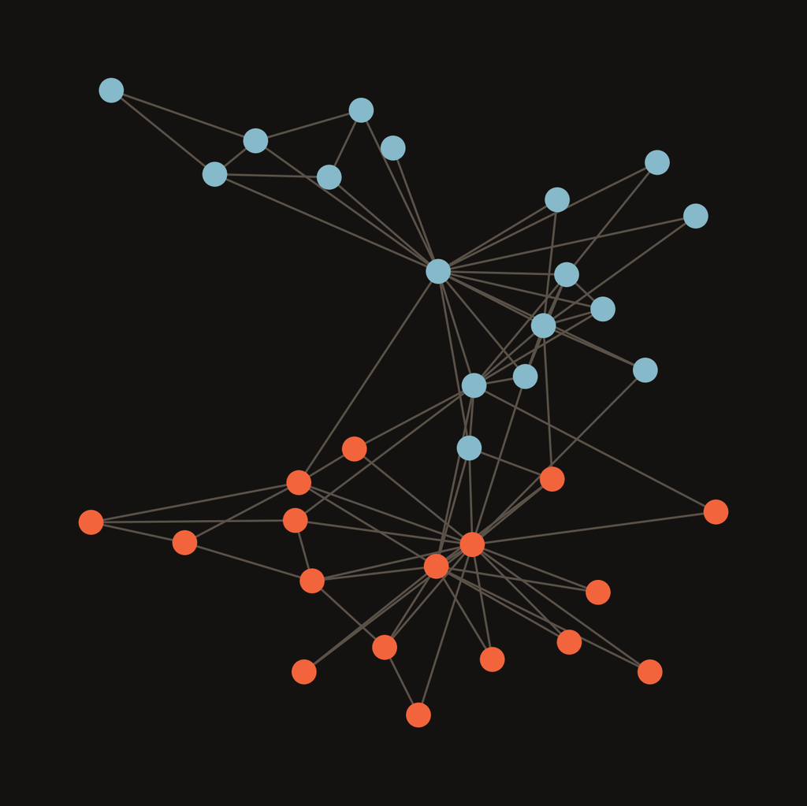

MADS-DAV

Data Analysis & Visualisation

# Networks

What a graph is, what it can be made of in your chat, what its measures add, and whether the groups an algorithm finds in it are real.

Lesson 7

Hogeschool Utrecht

Lesson 7. Until now a row was a thing: a message, a person, a penguin. Today the data is about how things are connected: who talks to whom, which topics come up together, which stations share a line. Six questions. The first two are about what a network is and what it can be made of in your own chat. The third is about what the numbers you can compute on a network add to the picture, and when they add nothing. The fourth is about how to look at one: a drawing or a matrix, and why you want both. The last two are about groups: an algorithm can find them, and then you have to ask whether they are there. The drawing on the cover is the karate club, the most famous small network in the field; we will meet it in question five.

Agenda

six questions

## Six questions for today

01

What is a graph?

A set of things and the relations between them. You choose both.

02

What are the nodes and edges in your chat?

People, but also places, hobbies and objects. Every edge is a rule.

03

What does a graph measure add?

Sometimes something deeper. Sometimes a column you already had.

04

Graph or heatmap?

Both, side by side. Sometimes one is much better.

05

Can an algorithm find the groups?

Yes. But sometimes it finds groups that aren't there.

06

Are the groups real?

Ask what the method finds in a network without any.

Agenda

MADS-DAV · 2

The agenda as six questions. One and two are about what a network is and what it can be made of: in the world, and in your own chat, where people are only the most obvious nodes. Three is about the numbers you can compute on a network, such as centrality and the clustering coefficient, and the one question to ask of each: what does it tell me that I did not have already? Four is about looking: a drawing and a matrix show different things, so draw both. Five and six are about groups: an algorithm finds them, and then you check whether they are there. Same rhythm as before: a question, real data, then the answer again in plain words. The notebooks follow along: 07.1 social graphs, 07.2 graph properties, 07.3 clusters in graphs.

3

▲ question 01

what is a graph?

## A graph is a set of things and the relations between them, and you choose both.

1 · The nodes

The things your question is about: people, stations, topics, bank accounts, posts.

2 · The edges

Pairs of nodes that are related: replied to, connected by a train, mentioned together, paid. An edge can have a direction and a weight.

3 · The parameters

There is often a wide variety of parameters you can change to rules that generate edges. Different parameters on the same data gives a different network.

Question one. A graph, or network, is the simplest structure for data about relations: a set of things, the nodes, and a set of pairs of things that are related, the edges. That is all. What makes it powerful is that the nodes and edges can be anything, and what makes it treacherous is the same thing: both are choices. The third card is the one to remember. A chat log does not contain a network; it contains messages. "Connected if they wrote within ten minutes of each other" is a rule that turns messages into a network, and "connected if one typed the other's name" is another rule that gives a different network with a different centre. Notebook 07.1 starts here.

■ 1 — what is a graph?

five nodes, five edges

## A graph is two sets: nodes and edges

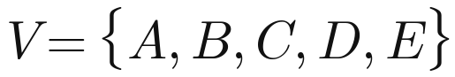

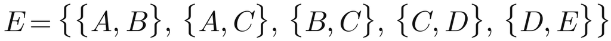

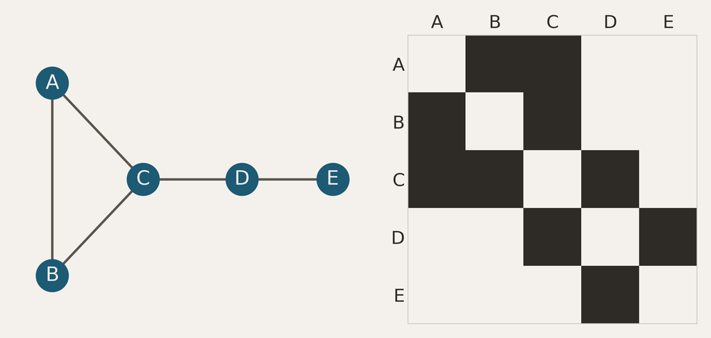

The drawing: a dot per node, a line per edge. Where the dots go is up to the drawing program.

The matrix: a row and a column per node, a dark cell where two are connected. The same information, and no layout.

Degree: the number of edges a node has. C has three, E has one.

1 / what is a graph?

MADS-DAV · 4

The whole definition. G is the pair V and E: V the set of nodes, E the set of edges, each edge a pair of nodes. That is the entire mathematical object; everything else is a way of showing it or a number computed from it. Two ways of showing it, and we will use both all lesson. The drawing is what everyone thinks of, and it is good at paths: you see at once that to get from A to E you go through C and D. But the positions are made up; a drawing program places the dots. The matrix is the same five edges as cells in a table. It has no layout, so it cannot mislead you about position, and it is symmetric because these edges have no direction. The first number you can compute is degree: how many edges a node has. C has three and sits on every path from the triangle to E; question three is about numbers like that, and what they add.

■ 1 — what is a graph?

topics, stations

## Nodes and edges can be anything

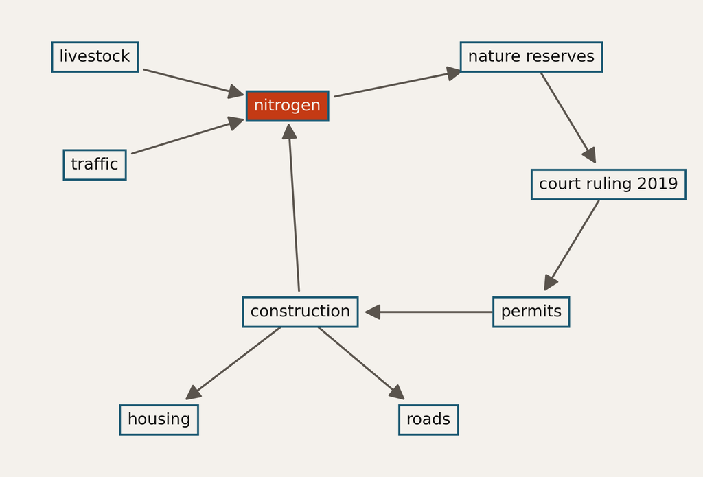

Policy: topics as nodes, “affects” as a directed edge. A court ruling on nitrogen stopped permits, and so construction, housing and roads.

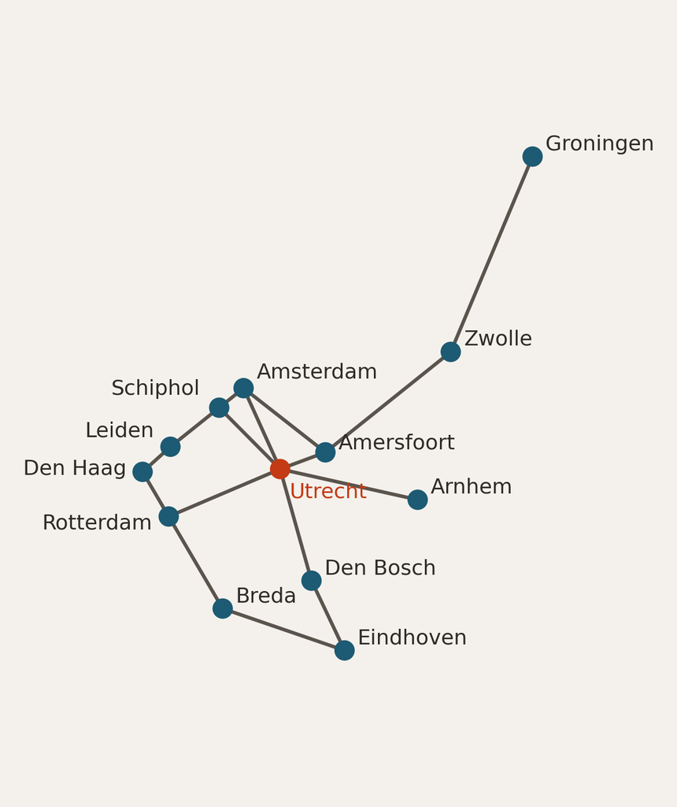

Trains: stations as nodes, a direct intercity as the edge, drawn on the map. Utrecht has the most edges.

1 / what is a graph?

MADS-DAV · 5

■ 1 — what is a graph?

money, likes

## Edges can have a weight, and nodes a kind

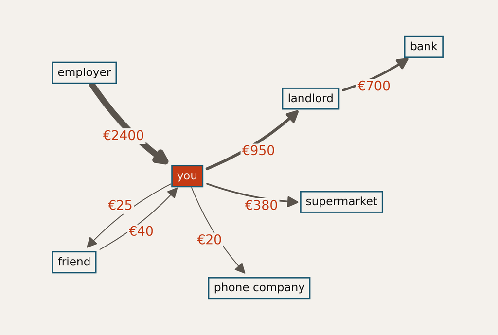

Money: accounts as nodes, a payment as a directed edge, the amount as its weight. Fraud detection looks for loops in graphs like this.

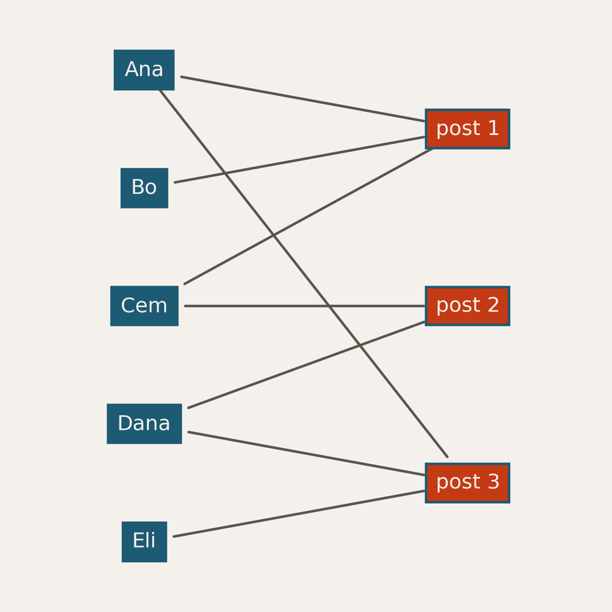

Likes: two kinds of node, people and posts. People connect only through posts; “liked the same post” is a second graph made from this one.

1 / what is a graph?

MADS-DAV · 6

Two more, each adding something to the definition. Money: bank accounts as nodes and payments as edges, with a direction, who paid whom, and a weight, how much. Banks and tax authorities analyse exactly this graph; money laundering shows up as money that travels in a loop and comes back to where it started, which no single row in a table of transactions shows you. Likes on a social network add a second idea: nodes of two kinds. People like posts; people never connect to people directly. Such a graph is called bipartite. And from it you can make another one: connect two people if they liked the same post. That is the sense in which a network is a decision. The same likes give a people-to-posts graph, a people-to-people graph and a posts-to-posts graph, each with its own centre, and which one you need depends on the question.

● 01 — what is a graph?

A graph is things and their relations, and you choose both.

G = (V, E): a set of things (nodes) and a set of relations (edges) between them. Drawn as dots and lines, or as a matrix.

Nodes can be people, stations, topics, accounts or posts. Edges can have a direction and a weight.

Every edge is a rule, and it often has parameters. Different parameters yield different networks.

7

Said again. A graph is a set of things and a set of relations between pairs of them, and it can be drawn or written down as a matrix. The things can be anything, and so can the relations, which may have a direction and a weight. The point to carry into the rest of the lesson is the last one: a network is never just in the data. You apply a rule, and the rule is part of what you report. The next question applies that to your own chat.

▲ question 02

what are the nodes and edges in your chat?

## Your chat holds many networks

1 · People

Who wrote within ten minutes of whom, who mentioned whom.

2 · topics

Places, hobbies, games, food, objects.

3 · A metric

“Mentioned within ten minutes, at least three times” is an example of a metric that defines an edge.

8

Question two: what could the network in your own chat be? People are the obvious nodes, and there are already several networks of people in one chat: who answered whom, who was writing at the same time, who mentioned whom by name. But nodes need not be people. The places you talk about, the hobbies, the films, the food, the objects: whatever a word list or a regex finds can be a node, and two of them are connected when they come up together, in the same message, the same ten minutes, the same day. The third card is the discipline: every edge is a measurement, so it needs a window and a threshold you could hand to someone else. The data for this question is an IRC channel, #ubuntu-uk in 2015, because it has a convention your WhatsApp chat lacks: people type the name of whoever they are answering. That lets us compare a rule you can use on your own chat with one you mostly cannot. Notebook 07.1.

■ 2 — nodes and edges in your chat

#ubuntu-uk, 2015 · 95,518 messages

## Two metrics to define a relationship

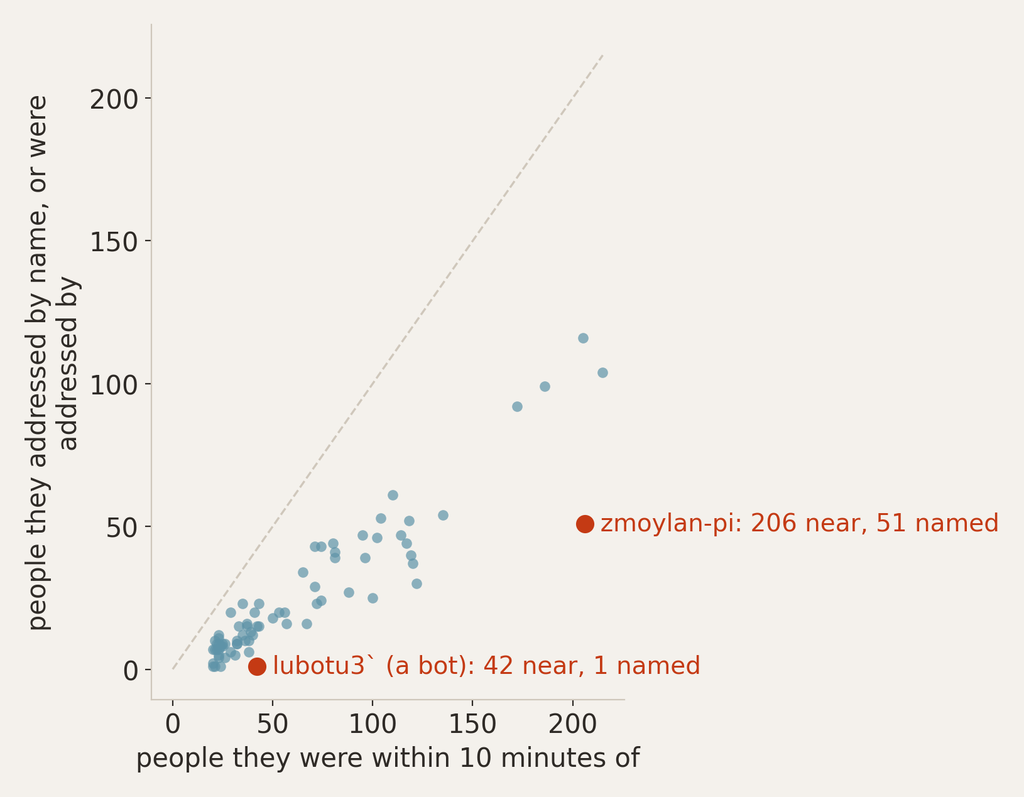

Time: two people are connected if they wrote within ten minutes of each other. 3,265 edges between 443 people.

Mentions: connected if one typed the other’s name. 1,146 edges.

Every dot sits below the dashed line: the nearby rule connects people to far more others than they ever spoke to.

The bot is near 42 people and named by one. zmoylan-pi is near 206 and named with 51.

2 / nodes and edges in your chat

MADS-DAV · 9

Two rules on the same messages. The nearby rule connects two people whenever they wrote within ten minutes of each other; it is the rule you can always use, because it needs nothing but timestamps. The named rule connects two people when one typed the other's name, the IRC habit for saying who you answer. Each dot here is a person: across, how many others the nearby rule connects them to; up, how many the named rule does. The dashed line is where the two would agree. Nobody is near it. The extreme case is the bot, lubotu3, which posts automatic messages: it was near 42 people and exactly one ever addressed it. zmoylan-pi, one of the busiest people in the channel, was near 206 people and talked by name with 51. So the nearby rule is mostly a measure of being online at the same time. That is not wrong; it is a different relation, and it needs to be called what it is. Notebook 07.1, sections 7.1.2 to 7.1.4.

■ 2 — nodes and edges in your chat

one minute to half an hour

## The window is a metric too

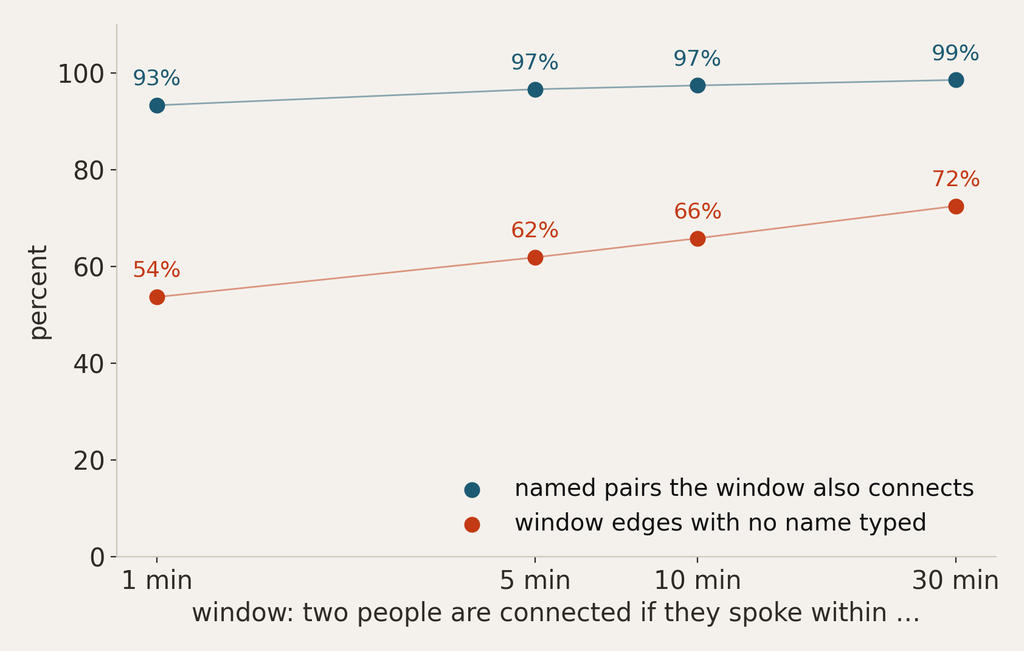

A longer window finds more pairs: 2,308 edges at one minute, 4,104 at thirty. The question is who they are.

Petrol: of the pairs who named each other, the share the window connects. 93% already at one minute: the real conversations are in.

Vermilion: so a longer window adds mostly people who happened to be online: edges with no name typed go from 54% to 72%. Choose it for your question, and put it in the caption.

2 / nodes and edges in your chat

MADS-DAV · 10

The nearby rule has a number in it, the window, and the number changes the network. The first thing to see is the obvious one: the longer the window, the more pairs it connects, from 2,308 edges at one minute to 4,104 at thirty. The question is what those extra edges are. Here we use the named rule as a check, because in this channel we can. The petrol line asks: of the pairs who addressed each other by name, how many does the window also connect? Almost all of them, 93 percent, already at one minute: people who talk to each other write close together, so a short window already has the real conversations. Then whatever a longer window adds must be something else, and the vermilion line says what: the share of edges with no name behind them climbs from 54 percent at one minute to 66 at ten and 72 at thirty. Make the window big enough and you find a relation between nearly everyone who was online at the same time. That is the core: a longer window does not find more conversation, it finds more bystanders. In your WhatsApp chat you cannot draw the vermilion line, because there are no names to check against. That is exactly why the window goes in the caption: it is the decision that made your network, and the reader needs it to judge what an edge means.

■ 2 — nodes and edges in your chat

23 things, 59 edges

## Topics: what is mentioned together

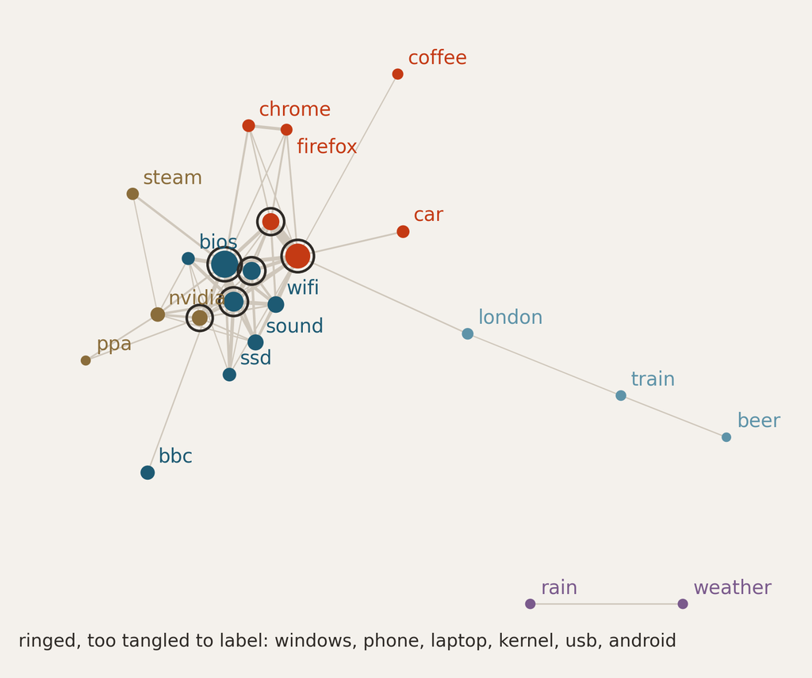

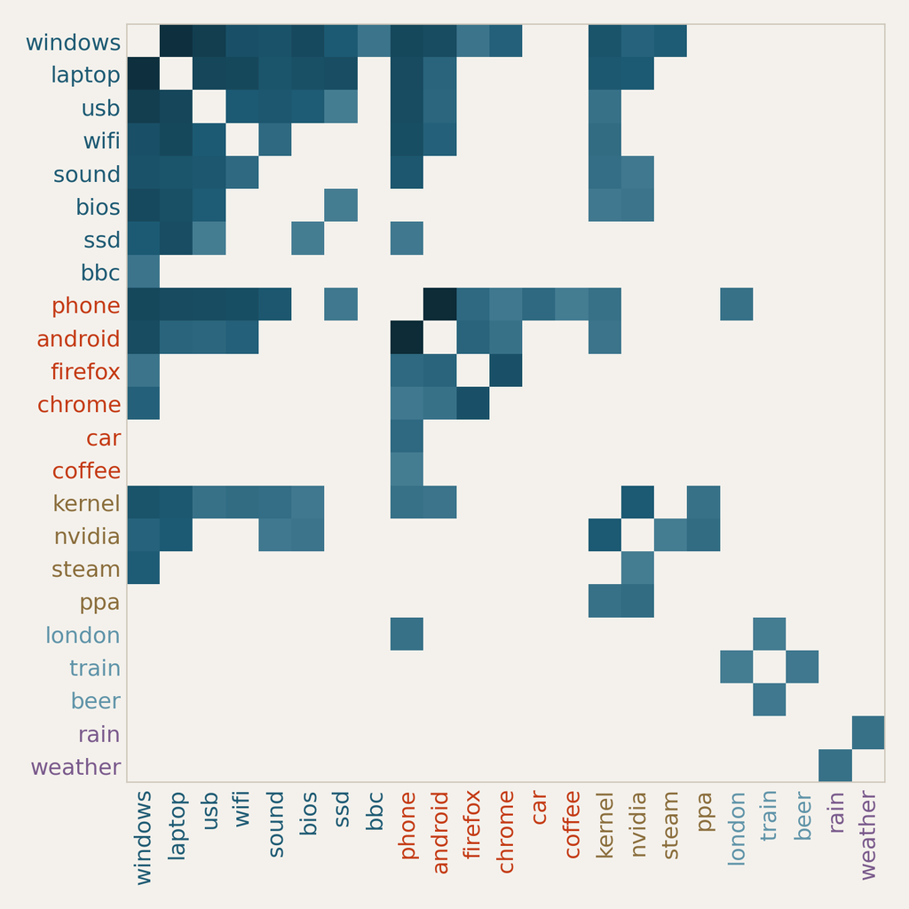

The metric: 23 words from a list, connected when both were mentioned in the same ten minutes at least eight times.

What it shows: a hardware knot, phones and browsers, drivers and games, and the channel’s off-topic life: London, trains, beer; rain and weather.

2 / nodes and edges in your chat

MADS-DAV · 11

The same channel with things as nodes instead of people. A word list of forty things, from wifi and kernel to tea, beer, London and the weather; 23 of them come up together often enough to stay. Two things are connected when both were mentioned in the same ten-minute stretch at least eight times. The drawing shows the shape at a glance: a tight knot of hardware words that all come up together, so tangled that its labels collide (they are ringed), and then smaller groups further out. The matrix, sorted by the same groups, makes the knot readable: windows, laptop, usb, wifi, sound and bios as one dark block. And the edges of the network are the interesting part for a social question: an Ubuntu help channel that also talks about London, trains and beer, and about the rain. That is the kind of network you can build from your own chat: places you mention together, hobbies, the things that come up on the same evening. Draw it twice, as here; question four is about why.

■ 2 — nodes and edges in your chat

before you build one

## Different lenses on the same dataset

| nodes | an edge when | measured as |
| --- | --- | --- |
| people | they wrote within ten minutes of each other | times, at least three |
| people | one @-mentions the other (groups only) | mentions, with a direction |
| places | both mentioned in the same message | messages |
| hobbies, games, food | both mentioned on the same day | days |
| people and places | a person mentions a place | mentions; two kinds of node |

2 / nodes and edges in your chat

MADS-DAV · 12

The exercise, before anyone writes code. The table is a start for a WhatsApp chat, not a list to copy. For people, the nearby rule is what you have; @-mentions exist only in group chats, and they have a direction, which makes the network directed. For things, every row is a word list plus a window: same message, same ten minutes, same day. The last row has two kinds of node, people and the places they mention, like the likes example: it tells you who talks about where, and from it you can make a people-to-people network of "mentions the same places". The point of listing several before choosing is that the choice becomes something you can defend: you can say why this network answers your question and the others do not. The goad coach asks this question too now, as the first step of a network analysis, and its next step asks what the numbers add, which is question three. Notebook 07.1, section 7.1.7.

● 02 — what are the nodes and edges in your chat?

Which network tells a story?

People are the obvious nodes. Places, hobbies and objects that come up together are nodes too.

If everything is connected with everything, there is no story. Often the most interesting story is about the holes in the network.

Your metrics (window, threshold) should go in the caption. They made the network.

13

Said again. Your chat contains many networks, of people and of things, and you build one by choosing a rule. The rule you will use most for people, being active within a window of each other, mostly measures being online together; in the IRC data two thirds of its edges at ten minutes had no conversation behind them. That does not make it useless. It makes it a specific relation, which you name honestly and state in the caption with its window and threshold.

▲ question 03

what does a graph measure add?

## What graph statistics can reveal

1 · hubs

Betweenness shows who or what is an intermediary in the network, a hub that often can control a lot.

2 · Triangles

Triangles tell something about interconnectedness at a deeper level and can reveal social dynamics.

3 · outliers

Statistics can tell you something about outliers in the networks. This can help you identify nodes that fulfill a special role.

14

Question three, the core of notebook 07.2. Once you have a network, there is a whole toolbox of numbers to compute on it: degree, betweenness, closeness, eigenvector centrality, clustering, and networkx gives you each in one line. The question to ask of each is what it adds to the picture you already had. Some measures add something real: betweenness finds brokers, people through whom others are connected, and the clustering coefficient measures something about a person that no column in a table can, whether the people around them know each other. Some add nothing: in a chat, the person with the most connections is mostly the person who writes the most, and you had that column before you built a graph. We go through all three, with a historical case, a piece of research that shows how far a network measure can reach, and a correlation that is easy to misread.

■ 3 — what does a graph measure add?

marriages between Florentine families, 1400s

## The Medici were the broker

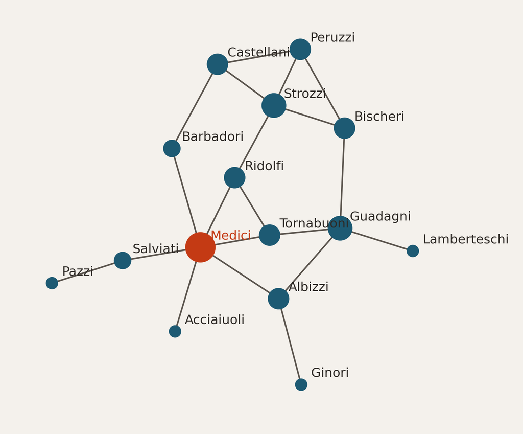

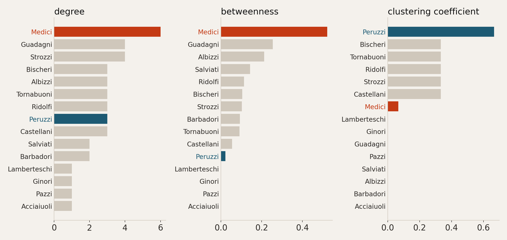

Hub: the Medici have 6 marriages, Guadagni and Strozzi 4. More, not different.

Outlier: betweenness 0.52, twice the next. Half the shortest routes between other families run through them.

Triangles: the Peruzzi’s in-laws married each other, 0.67. The Medici’s did not, 0.07.

3 / what does a graph measure add? · Padgett & Ansell 1993

MADS-DAV · 15

The three things a graph measure can reveal, from the last slide, in one network. Padgett and Ansell collected the marriages between the elite families of fifteenth-century Florence, and asked how the Medici, who were not the richest or the oldest family, came to rule the city. Each bar chart shows all fifteen families, sorted by its own measure, so the top of each is visible. Degree, the hub question: the Medici have six marriage ties, Guadagni and Strozzi four. More, but not a different kind of family. Betweenness: of all the shortest paths between pairs of other families, about half run through the Medici, twice the share of anyone else. That is the outlier, and it is an outlier in a column that only exists in the network. Clustering, the triangles: the Peruzzi score 0.67, because the families they married into, the Strozzi, the Castellani, the Bischeri, also married each other: the old oligarch families, a closed bloc. The Medici score 0.07: the families they married hardly married each other. Every alliance went through the Medici, and their partners could not coordinate without them. That is a position you can only see in the network: a broker has high betweenness and low clustering. This network is in networkx as florentine_families_graph; notebook 07.2.

■ 3 — what does a graph measure add?

triadic closure

## Are your friends friends with each other?

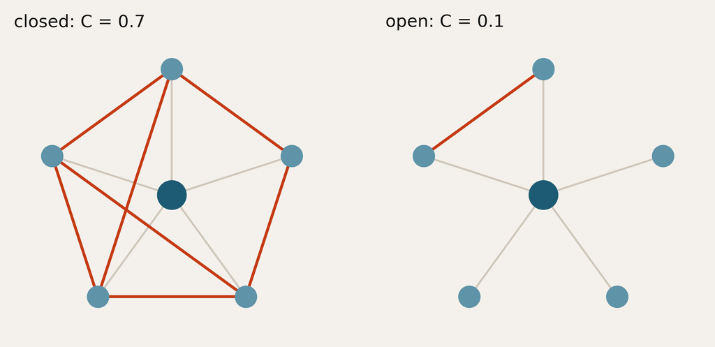

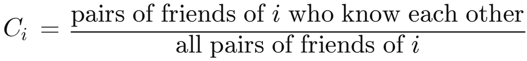

Closed: 7 of the 10 pairs among the five friends know each other. C = 0.7.

Open: 1 of 10. The person in the middle is all that holds the circle together.

Triadic closure: two people with a friend in common tend to become friends. Social networks are full of triangles.

Two readings of social capital: closed gives support and trust (Coleman). Open gives control: whoever sits in the middle decides what passes (Burt).

3 / what does a graph measure add?

MADS-DAV · 16

The clustering coefficient, the measure that the Medici scored so low on. Take a person and their friends. Among five friends there are ten possible pairs. Count how many of those pairs are friends themselves and divide by ten. On the left seven are, so C is 0.7: a closed circle where everyone knows everyone. On the right one is: an open circle, held together only by the person in the middle. The reason this matters is triadic closure, one of the oldest observations in sociology: if two people have a friend in common, they tend to become friends. They meet at that friend's birthday, they hear about each other. So real social networks have far more triangles than random ones, and a person whose circle stays open is unusual. Sociology reads that difference in two ways. James Coleman (1988) saw closure as social capital: when your friends know each other, they share norms, trust each other and notice when something is wrong. Ronald Burt (1992) found social capital in the open circle instead: whoever sits between people who do not know each other hears more, and decides what passes between them; he called the gaps structural holes. Both are right, depending on what the ties carry and what you need from them. The Medici on the last slide are Burt's case: marriages as alliances, and every alliance through them. The girls of Bearman and Moody, two slides on, are Coleman's: friendships as support, and an open circle as support that is missing. The same coefficient means opposite things, so a network measure says nothing without what its ties are. And remember the triangles: in question six they come back to fool a community algorithm.

■ 3 — what does a graph measure add?

hubs and triangles together

## A small world: closed circles, and a few shortcuts

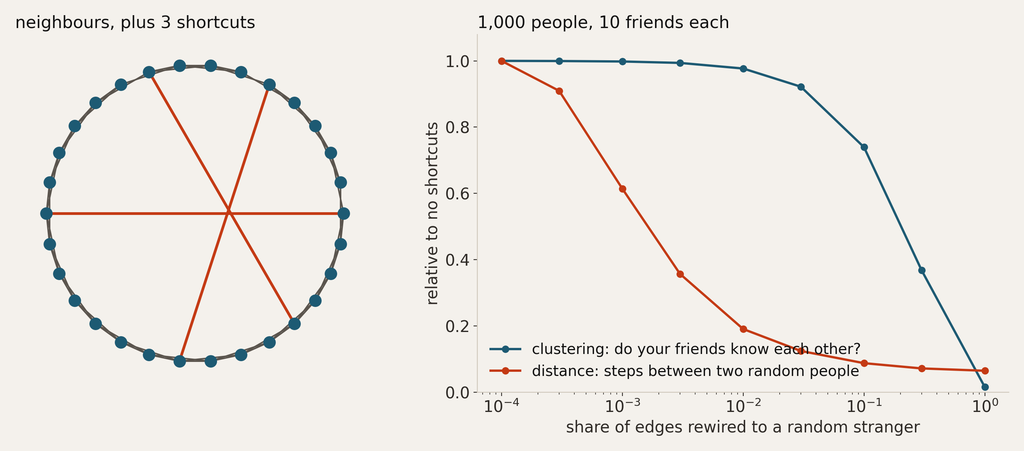

Rewire 1% of the edges to random strangers: the distance between two people drops to a fifth. Clustering stays at 98%.

Real networks are like this. Milgram’s letters reached a stranger in about six steps. Facebook in 2011: 721 million people, 4.74 steps on average.

What follows: news, rumours and viruses cross a huge network in a few steps, through its hubs and brokers. A short distance in your chat is no finding; every social network has one.

3 / what does a graph measure add? · Watts & Strogatz 1998; Backstrom et al. 2012

MADS-DAV · 17

Hubs and triangles together give one of the best-known results in network science. Watts and Strogatz, in Nature in 1998, started from a world of closed circles: everyone knows their neighbours, and the neighbours know each other, so clustering is high, but a message from one side of the ring to the other takes fifty steps. Then they rewired a small share of the edges to random strangers. The plot on the right repeats that for a thousand people with ten friends each. At one percent rewired, the mean distance between two people has fallen to a fifth, while clustering is still at 98 percent of what it was. A few shortcuts are enough to make the whole world close, without opening anyone's circle. That combination, high clustering and short paths, is called a small world, and real social networks are small worlds. Milgram's experiment in the 1960s asked people to pass a letter to a stranger through acquaintances; the letters that arrived took about six steps, which is where 'six degrees of separation' comes from. In 2011 Backstrom and colleagues measured the whole of Facebook, 721 million active users: the average distance was 4.74. What follows from it: anything that spreads person to person, news, a rumour, a virus, crosses even a huge network in a few steps, and it does so through the shortcuts, the hubs and brokers like the Medici. Take the Medici out of Florence and three families lose every route to the others. And a caution for your own analysis: a short average distance in your chat is not a finding; every social network has one.

■ 3 — what does a graph measure add?

13,465 American adolescents, grades 7 to 12

## An open friendship circle, and thoughts of suicide

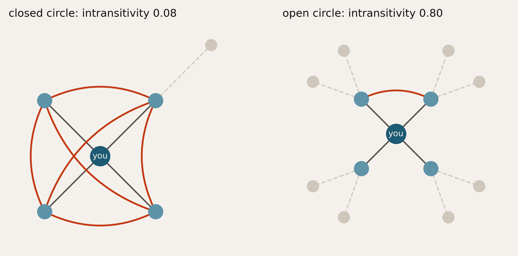

The measure: of your friends’ friends, the share who are not your own friends: the triangles around you that did not close. The paper calls it intransitivity.

Girls: a fully open circle against a fully closed one, 2.2 times the odds of having seriously thought about suicide (1 = no difference). Isolation, depression and self-esteem held equal.

Isolation you would expect, and it counts too: 2.0. But having friends does not protect you if they do not know each other.

Boys: neither was found. For them, as for girls, a friend’s suicide attempt counted: 2.7 times.

3 / what does a graph measure add? · Bearman & Moody 2004, AJPH 94(1) · circles made up

MADS-DAV · 18

How far a network measure can reach. Bearman and Moody used Add Health, a large American survey in which 13,465 students in grades 7 to 12 named their friends, so the researchers could build the friendship network of each school. For every student they counted the friends of their friends, and asked which share of those are not the student's own friends. Each such person is a triangle around you that did not close: you know A, A knows B, and you do not know B. So this is triadic closure from two slides ago, measured from the other side, and one step further out than the clustering coefficient. The paper calls it intransitivity. It has no drawing of it, so here are two made-up circles: on the left a closed circle, where your friends' friends are mostly your friends, 0.08; on the right an open one, four friends with friends of their own whom you do not know, 0.80. The outcome was a survey question: during the past twelve months, did you ever seriously think about committing suicide? The number to read is 2.2 against 1, where 1 means no difference. The index runs from 0, fully closed, to 1, fully open, and a girl at 1 had 2.2 times the odds of a girl at 0, with everything else in the model held equal: whether she was isolated, depression, self-esteem, family circumstances, a friend's suicide attempt. Most students sit in between; the average was 0.69. The number of friends was not in the model, only whether a student was isolated. Isolation is the risk you would expect, and it counts: isolated girls had 2.0 times the odds. The striking part is that the open circle is at least as strong, and it is about girls who do have friends. Having a circle of friends says little if that circle does not close. For boys neither effect was found: their odds ratios were 0.75 and 0.67, with intervals well across 1. That is not that isolated boys never think about it; isolation and open circles did not change the odds for boys. The authors do not explain the difference beyond one sentence: adolescent males are more impervious to social context. What did matter for boys, as for girls, was a friend who had attempted suicide, 2.7 times the odds, and a family member who had, 2.1. Two cautions. It is a survey at one moment, so it shows an association, not which came first. And the point for us is the method: a number that only exists in the network said something that the individual columns, including a depression score, did not. Borrowing it needs care, though: notebook 07.2, at the end of section 7.2.5, computes it on the IRC chat, where it turns out to be degree upside down, because nothing there caps how many people you are connected to. Add Health capped it at five female and five male friends.

■ 3 — what does a graph measure add?

#ubuntu-uk, nearby rule

## How you construct an edge has impact downstream

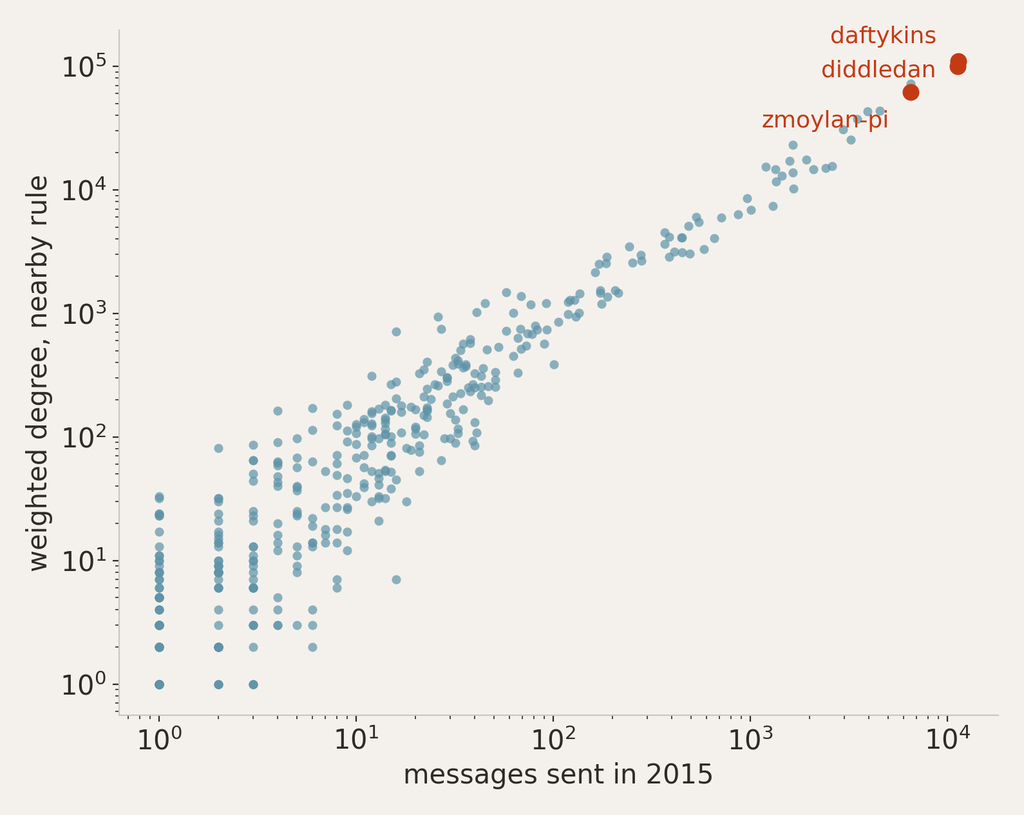

Each dot is a person. Across: messages sent in 2015. Up: weighted degree, how often someone else wrote within ten minutes of them.

The cloud is a line. Most of those pairs never named each other: the more you write, the more often someone happens to write near you.

A centrality that repeats a column adds nothing. Before you report one, put it next to a column you already had: here the message count.

3 / what does a graph measure add?

MADS-DAV · 19

And the other side: a measure that adds nothing. Weighted degree under the nearby rule counts, for each person, how many times someone else wrote within ten minutes of them. Plot it against the plain message count and the cloud is a straight band across four orders of magnitude. Of course it is: the more you write, the more often someone else happens to write near you. So "daftykins is the most central person in the channel" says the same as "daftykins wrote the most messages", which you knew from a value_counts in lesson one. Remember slide 10: two thirds of these nearby pairs never addressed each other, so an edge here is mostly a coincidence of timing, and counting coincidences mostly counts messages. That is the test for every network measure you report: compare it with a column you already had, here the message count, and draw the scatter. If it is a line, say so and drop the measure. If people break away from the line, those are the interesting ones: someone who writes little and is central, or writes a lot and is talked to by nobody. One doubt remains about a picture like this one, and it is the next slide: whether the line is carried by the few loudest accounts.

■ 3 — what does a graph measure add?

the same check, two outcomes

## Is the line carried by the loudest few?

Ranks give every person one vote. Spearman’s ρ correlates the ranks, so it asks whether the order holds for the whole crowd.

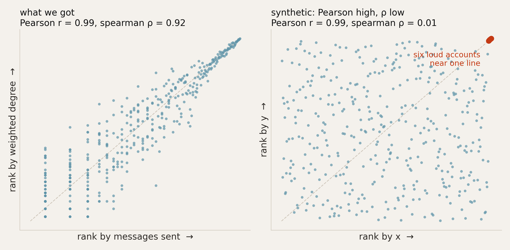

Pearson is high. Spearman confirms this is not just a few outliers

What would a low spearman have looked like.

3 / what does a graph measure add? · right panel synthetic

MADS-DAV · 20

The scatter on the last slide raises one fair doubt. A handful of accounts sent thousands of messages, and an ordinary Pearson correlation weighs every point by how far it lies from the mean. So the straight line could be carried by those few, with the crowd doing something else. The question is whether the crowd lines up too. That is what ranks are for. Give the busiest person rank 1, the next rank 2, on both columns, and correlate the ranks: that is spearman's rho. Eleven thousand messages buy the top rank and nothing more, so every person has one vote. Both panels are drawn in rank space, more to the right and up. On the left, what we got: rho is 0.92, the order holds all the way down. Be honest about how much that adds: the log-log scatter already showed a straight band over four orders of magnitude, so the answer to the doubt is no, and you could see it. Pearson on the logs is 0.94, and without the ten loudest accounts Pearson is still 0.96; the loud accounts were never carrying it. On the right, what the other answer would have looked like. It is made up, and labelled as such: a random crowd and six loud accounts on one line. Pearson says 0.99, rho says 0.01. Then "central means busy" holds for the top six and for nobody else, and the next step would be to look at the crowd without them. Either way, weighted degree repeats the message count. The next slide asks whether another degree does better. Notebook 07.2, section 7.2.4.

■ 3 — what does a graph measure add?

the same check, another degree

## Which degree adds something?

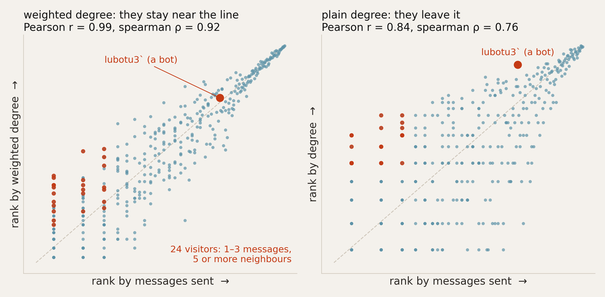

Weighted degree counts every time someone wrote near you, so each message you send adds to it. ρ 0.92: it repeats the message count.

Plain degree counts how many different people you were near. A few messages at a busy moment buy many neighbours. ρ 0.76.

Marked in both: the bot and 24 visitors with one to three messages. Weighted degree keeps the bot in place; plain degree lifts it 70 places, the visitors a median of 148.

What plain degree adds is presence, not conversation. The people off the line are the ones to look at.

3 / what does a graph measure add? · #ubuntu-uk, nearby rule

MADS-DAV · 21

Slide 20 settled one doubt about weighted degree: the crowd lines up, not just the loudest few. So weighted degree is a message counter. Is there a degree that is not? Weighted degree counts every time someone else wrote within ten minutes of you, so every message you send adds to it, and it cannot help following the message count. Plain degree counts something else: how many different people you were near, however often. Run the same rank check on both, and mark the same people in both panels: the bot lubotu3, which posts a link whenever someone types a bug number, and 24 visitors who wrote one to three messages and still have five or more neighbours. On the left they stay in the band. The bot is 106th by messages and 98th by weighted degree, and the visitors climb a median of 54 places, inside the cloud. On the right they leave it: the bot climbs to 36th, seventy places, and the visitors a median of 148, because their few messages landed in a busy ten minutes and every person writing then became a neighbour. So plain degree, at rho 0.76, does add something to the message count, and what it adds is presence: being there when others are talking, not talking with them. That is not useless. A list of people who are everywhere and say little is something to look at, and the bot is the first name on it. The lesson is the order of work: put the measure next to a column you already had, and when people leave the line, look at who they are before you give the measure a name. Notebook 07.2, sections 7.2.3 and 7.2.4.

■ 3 — what does a graph measure add?

the same ranking, four windows

## Does the window decide who is central?

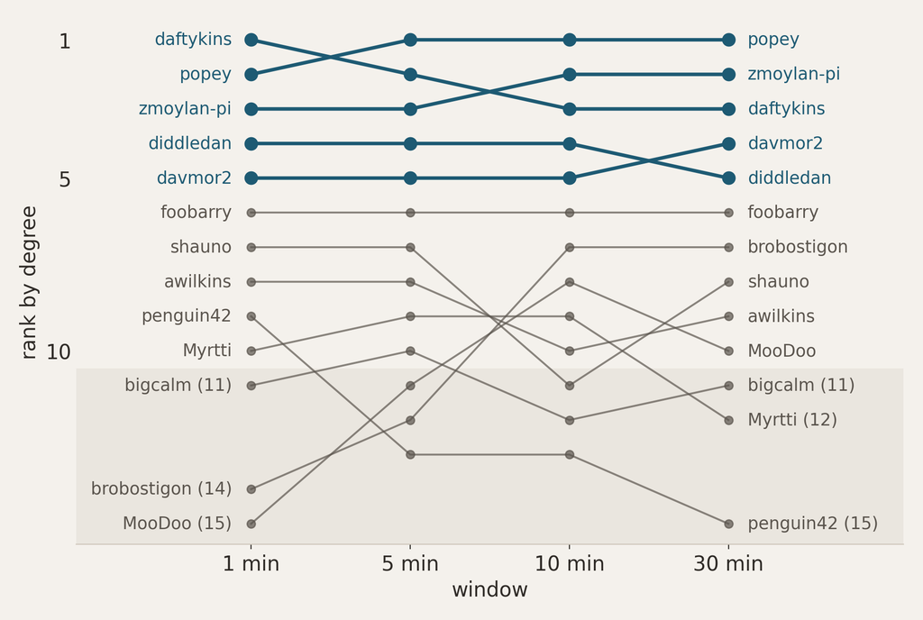

Why ask: a longer window adds edges, mostly bystanders (slide 10). If it also reshuffles who has the most, “most central” is a fact about the window.

What we did: rank everyone by degree at 1, 5, 10 and 30 minutes, and follow the top.

What we see: the same five on top at every window, swapping places. Spearman’s ρ with the 10-minute ranking: 0.92, 0.98, 0.95.

Had it moved: not wrong, but the ranking belongs to the window. Report it with its window, and show who moves.

3 / what does a graph measure add?

MADS-DAV · 22

A second use of spearman, and a different question. The last slides asked whether a measure adds something to a column you already had. This one asks whether a result survives a choice you made. Slide 10 showed that the window decides how many edges there are: a longer window adds edges, mostly between people who happened to be online. The worry is that it also decides who comes out on top. So rebuild the graph at one, five, ten and thirty minutes, rank everyone by degree each time, and follow the people at the top. The picture answers it: the same five people, popey, zmoylan-pi, daftykins, diddledan and davmor2, are the top five at every window. They swap places among themselves, and below them people move a few places; brobostigon climbs from 14th at one minute to 7th at ten. Spearman puts the whole ranking, everyone both graphs contain, in one number: against the ten-minute ranking 0.92 at one minute, 0.98 at five and 0.95 at thirty. So 'who is most central' does not depend on the window here. Had the lines crossed wildly, that would not make the analysis wrong: a short window misses conversations, a long one adds bystanders, and neither is the true network. It would mean that the ranking is a fact about the window, so you report it with its window and show who moves. Lesson 5 did the same with typing habits four years apart. The notebook also runs betweenness and clustering, and warns about small rankings: for eight people a rho of 0.6 can come from chance alone. Notebook 07.2, section 7.2.9.

23

● 03 — what does a graph measure add?

Hubs, connectedness, outliers.

Hubs. Betweenness found the Medici. A few hubs make even a huge network small.

Connectedness. Do friends know each other? This tells you a lot about how close a group is.

Outliers. Put each measure next to a column you had. The line repeats it; the people off the line are the finding, if the ranking survives your window.

Said again, in the three words of the start of this question. Hubs: some nodes hold a network together. Betweenness found the Medici, who were not the biggest family but the one every route ran through, between families who did not marry each other; and a few such shortcuts are why even a network of hundreds of millions of people is only a few steps across. Connectedness: whether the people around a node know each other, counted in triangles. Real social networks are full of them, and Bearman and Moody showed how much it can matter when a circle stays open. Outliers: many measures in a chat say nothing new, because activity drives everything. So put each measure next to a column you already had and draw the scatter. If it is a line, the measure repeats the column, like weighted degree and the message count. The people who leave the line are the finding: a bot and a crowd of visitors under plain degree. And before you report any ranking, check that it survives the choices you made, like the window: here the same five people come out on top at every window.

▲ question 04

graph or heatmap?

## A graph or a matrix?

1 · The layout

A layout puts each node somewhere, by a rule with a random seed in it. Position is not data.

2 · The matrix

A heatmap with a row and a column per node. No layout and no tangle, but the order of the rows is a choice too.

3 · the story

Some stories require a graph, some a matrix.

24

Question four: how to look at a network. There are two ways and they complement each other. The drawing, dots and lines, is what everyone expects, and it is good at what a network is about: paths, hubs, bridges, who connects to whom through whom. But someone has to decide where the dots go, and a layout algorithm decides it with a rule and a random seed, so position in the picture is not a property of the data. The matrix is a heatmap: one row and one column per node and a coloured cell for every edge, darker for heavier. It has no layout to mislead you, it never turns into a hairball, and it shows weights as numbers. What it hides is paths, and its row order is a choice that decides what you see. So the habit: always draw both, side by side. Sometimes they tell the same story; often one of them is much better, and you can only find out which by making both. Notebook 07.2, sections 7.2.6 to 7.2.8.

■ 4 — graph or heatmap?

mention graph, people with six partners or more

## One graph, two layouts, identical degrees

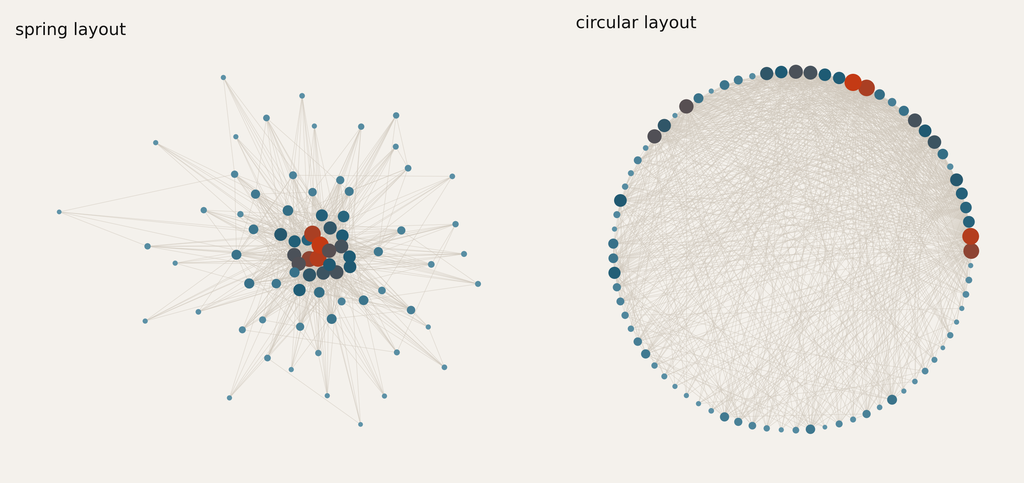

Spring: edges pull, nodes push apart. The hubs land in the middle and everyone else around them.

Circular: the same edges and the same hubs, now on the rim with everyone else. The circle shows nothing.

“On the edge of the network” is a statement about a layout.

4 / graph or heatmap?

MADS-DAV · 25

The first problem with drawings: the layout. This is one network, the mention graph of the people with at least six conversation partners, drawn twice. Colour and size are degree, the same in both panels; only the positions differ. The spring layout treats every edge as a spring and every node as a charge that pushes the others away, and lets the system settle: the hubs, which have many springs, are pulled into the middle, and that is why the picture looks like a star. The circular layout simply puts all nodes on a circle in the order they come, so the hubs sit on the rim among everyone else and the inside is a haze of lines. Neither picture is wrong; they are the same graph. But a sentence like "she is on the edge of the network" is true in one panel and false in the other, so it is a sentence about the layout. Say what the data says: her degree, or how many steps she is from the busiest person. Notebook 07.2, section 7.2.7.

■ 4 — graph or heatmap?

the same people, sorted by degree

## The same network as a matrix

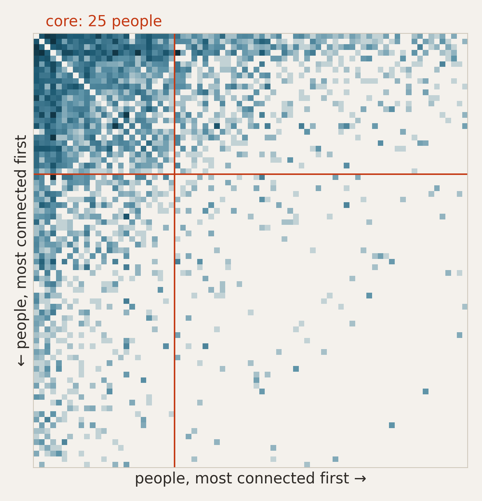

One row and one column per person, most connected first. A cell is coloured when the two mentioned each other; darker is more often.

Inside the lines: the core. Remove everyone with fewer than k ties left in the group, and repeat until nobody drops out.

The highest k that leaves anyone is 19: 25 people, each tied to at least 19 of the others. 91% of their pairs talk.

Their rows and columns: they talk with 35% of everyone else. Bottom right: the rest, among themselves, 5%.

That is a hub network. The spring layout let you guess it; here you can read it off.

4 / graph or heatmap?

MADS-DAV · 26

The same people, the same edges, as an adjacency matrix. Each person is one row and one column, sorted by degree, so the busiest person is the first row and the first column. A cell is coloured when the two mentioned each other, and darker the more often, on a log scale because a few pairs talk thousands of times. Read it like a map. The top-left corner is dark: the busiest people all talk to each other. The top rows and the left columns are long bands that reach far to the right and far down: the busiest people also talk to almost everyone else. And the bottom-right, the conversations among the less busy people, is nearly empty. The two vermilion lines mark off the core, and where to draw them is not a matter of taste. The k-core of a network is the largest group in which everyone is tied to at least k others of that group. You find it by peeling: remove everyone with fewer than k ties, which lowers the count of their neighbours, remove whoever drops below k next, and repeat until nobody drops out. Try k = 1, 2, 3 and so on; the group shrinks, and at k = 20 nobody is left. So the highest k is 19, reached by 25 people, each tied to at least 19 of the other 24. networkx does the peeling in one call, k_core. They are also the 25 most connected, so the core sits exactly in the top-left corner, the block your eye already picks out. A line on a matrix is a boundary you drew, and it comes back in question five as the cut between two clubs and in question six as the borders of communities. Inside the lines 91 percent of the 300 pairs talk, and the first 15 people are all tied to each other. Their rows run on to 35 percent of everyone else, among the rest only 5 percent of pairs talk, and 72 percent of all mentions stay inside the core. That is the shape of a hub network: a channel where questions go to a few regulars. The spring layout made you suspect it with its star; the matrix lets you check it, cell by cell, without any layout in between. In question six we sort the same matrix by communities, and this shape returns.

■ 4 — graph or heatmap?

sparse and spatial

## Sometimes the drawing wins

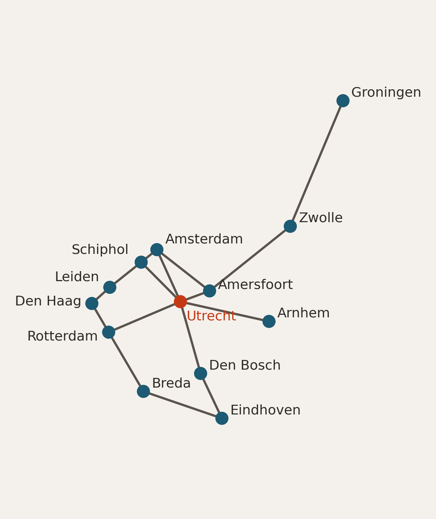

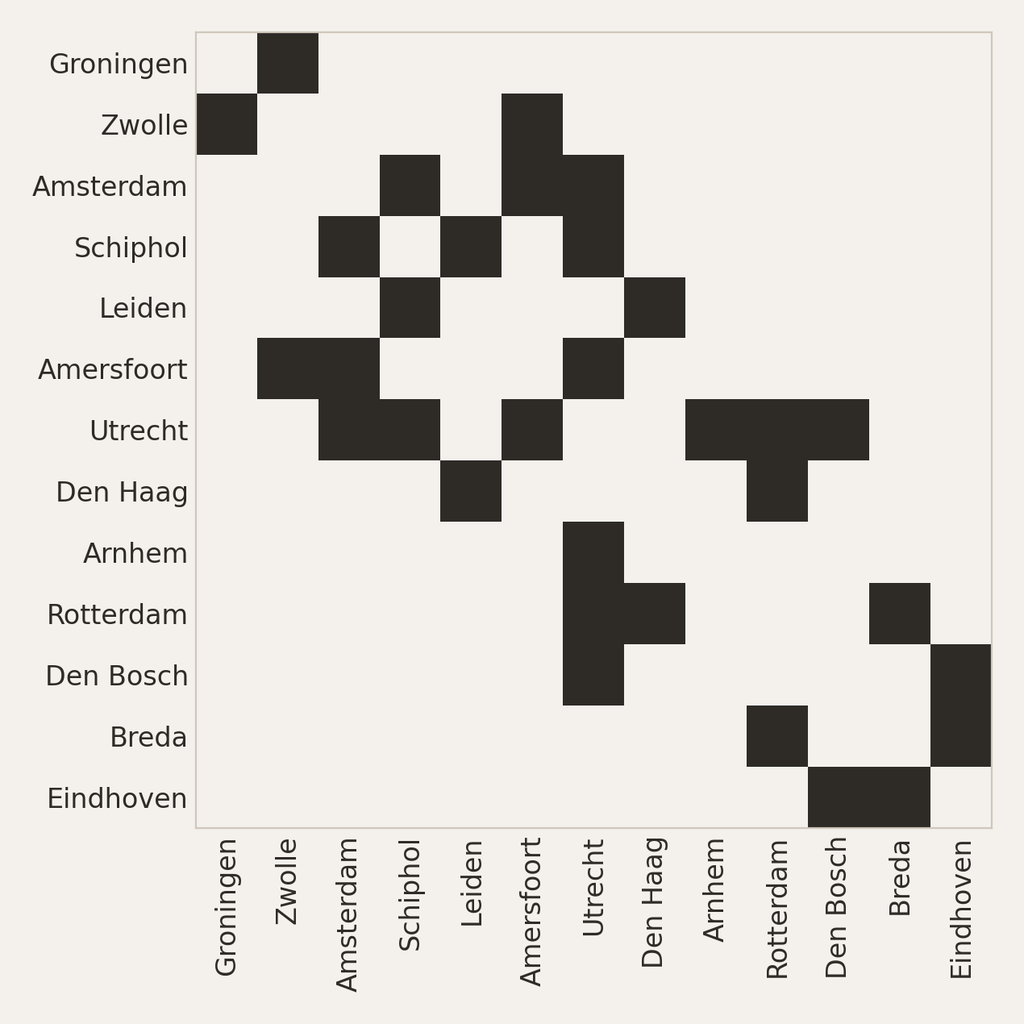

Most people prefer the graph. In metros, the graph often does not follow actual coordinates.

Try to navigate in the matrix if you want to travel from Zwolle to Eindhoven. You can do it, but it is really a different experience.

4 / graph or heatmap?

MADS-DAV · 27

■ 4 — graph or heatmap?

the eight busiest people, who names whom

## Sometimes the matrix wins

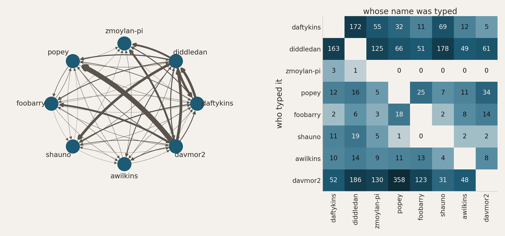

The drawing: 50 arrows, two between most pairs. It shows that everyone names everyone, not who names whom.

The matrix: row = who typed the name, column = whose. zmoylan-pi is named 332 times by these seven and names them 4 times.

4 / graph or heatmap?

MADS-DAV · 28

When the matrix wins. An @-mention has a direction: one person types the other's name. So take the eight busiest people under the named rule and keep the direction. Fifty of the 56 possible arrows are there, most pairs in both directions, with very different weights. As a drawing that is a ring full of arrows on top of each other: you can see that everyone addresses everyone, and you cannot see who addresses whom, let alone how often. The matrix gives every ordered pair its own cell: the row is who typed the name, the column whose name it was. A directed network gives a matrix that is not symmetric, and the asymmetry is the story. zmoylan-pi is named 332 times by the other seven and names them 4 times: a person people talk to, who answers without typing names. davmor2 is the opposite: 928 names typed, 124 received. daftykins and diddledan address each other most, 172 and 163 times. A dense, weighted, directed network is a table of numbers, and a table of numbers is what a heatmap is for. Your WhatsApp group of six or eight friends is very likely this case.

■ 4 — graph or heatmap?

both views, and every decision a slider

## A dashboard: ask your agent for one

Build me an artifact dashboard from irc_graph_windows.json: 80 people, their named edges, and their nearby edges at four windows.

– Left a force-directed graph, right the adjacency matrix as a heatmap, always the same edges.

– A switch for the rule, a slider for the window and one for the minimum weight.

– Hovering a person highlights them in both views.

– A caption with the rule, the window, the threshold and the number of edges left.

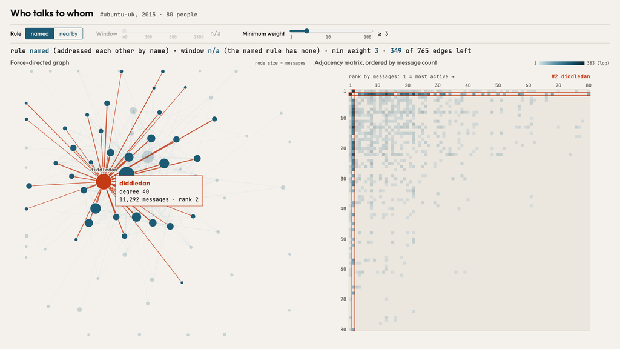

Built from this prompt by an agent: dashboards/lesson7-dashboard.html. Check 1: window 60 → 1800 s, edges 1,212 → 1,606. Check 2: the caption says rule, window, threshold.

4 / graph or heatmap?

MADS-DAV · 29

The rule, the window, the threshold: every decision in this question is a number you would like to drag and watch the network answer. That is what a dashboard is for, and you no longer have to write one. Streamlit still works, and dashboard_5.py in the repository is the old version of this idea, but for exploring your own graph it is much faster to describe the dashboard to your agent and let it build a page: one interactive file with sliders and hover, that opens in a browser. The division of labour matters. The network is computed in the notebook, where you can check it; you export the numbers, and the page only draws them. This one was built by an agent from exactly the prompt on the left, and it is in the repository as dashboards/lesson7-dashboard.html. Here it shows the named rule at a minimum weight of three, with diddledan highlighted in both views: the drawing shows the star around them, the matrix shows the same person as one row and one column. Notice that the prompt asks for both views side by side, which is this whole question. And check what comes back, because the agent will not: move the window slider and see whether the edge count changes, here from 1,212 at sixty seconds to 1,606 at thirty minutes, which tells you the page recomputes rather than redraws; and make sure the decisions are in the caption, because a screenshot of a dashboard travels without its sliders. Notebook 07.1, section 7.1.6.

● 04 — graph or heatmap?

Focus on the story

Both tell a very different story with the same data.

It is up to you to pick the one the tells your story the best.

30

Said again. Draw every network twice: as dots and lines, and as a matrix. The drawing is best at paths and hubs but its positions are invented by a layout, so never describe a node by where it sits. The matrix has no layout, never tangles and shows weights, and once you sort its rows by degree or by groups its shape becomes readable. Which one carries the point depends on the network: a sparse network with real geography wants the drawing, a dense weighted one wants the matrix. A dashboard from your agent with both views and the decisions as sliders is the quickest way to find out for your own chat.

▲ question 05

can an algorithm find the groups?

## Groups help you understand what is going on in the network, so how to find them.

1 · By eye

Two clumps with few lines between them are two groups. In a sorted matrix they are two blocks.

2 · By algorithm

An eigenvector cuts a graph in two. Louvain finds as many groups as raise modularity.

3 · Story

When you find a group, ask yourself: what does this tell me about the network? Some algorithms will always find a group and will tell you nothing.

31

Question five, the start of notebook 07.3. Networks often fall apart into groups: friend circles, departments, factions. You can see that by eye, in a drawing as clumps with few lines between them, or in a matrix sorted the right way as blocks along the diagonal. And it can be found automatically. Two methods today: the Fiedler vector, an eigenvector of the graph that cuts it into two halves with as few edges between them as possible, and louvain, which finds as many groups as raise a score called modularity. The third card is the attitude. An algorithm that finds groups you could already see is not redundant: it is a confirmation, it makes the cut precise, and it scales to networks too big to look at. The strongest case is when the groups also match something that was measured separately from the network. The karate club is that case.

■ 5 — can an algorithm find the groups?

34 members, 78 friendships · Zachary 1977

## A karate club that split in two

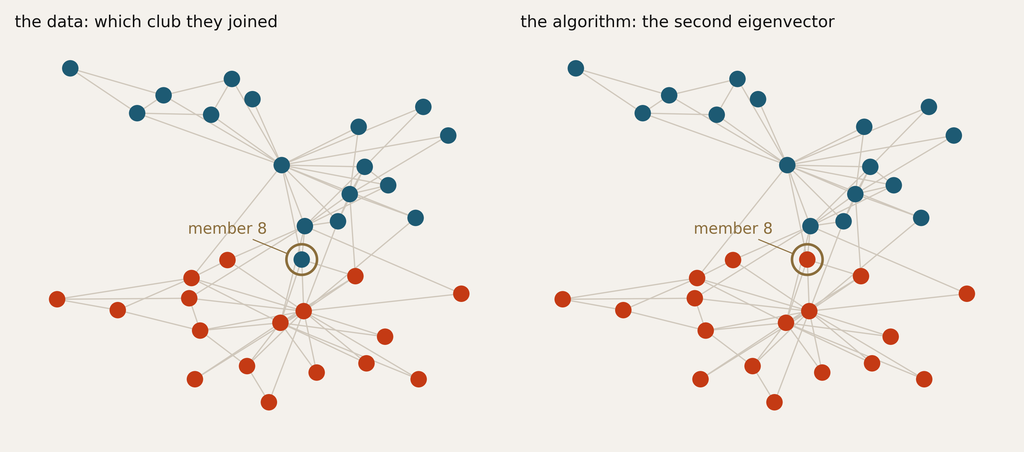

The data: which club each member joined after the split, drawn on the friendships recorded before it.

The algorithm: a cut through the same lines, nothing else. 33 of 34 land on the side they joined; member 8, ringed, is the miss.

5 / can an algorithm find the groups?

MADS-DAV · 32

The most famous small network in the field. In the early 1970s the anthropologist Wayne Zachary studied a university karate club for two years, and recorded which of its 34 members met each other outside the lessons. During that time a conflict grew between the instructor, member 0, and the club's president, member 33, about the price of lessons, and the club split: the instructor started a new club, and every member chose a side. So this network comes with an answer that was not part of it. Both panels are the same drawing of the friendships Zachary recorded before the split. On the left, coloured by the data: the club each member joined. On the right, coloured by an algorithm that was given only the lines: the cut by the second eigenvector, which the next slide opens up. It puts 33 of the 34 members on the side they joined. The miss is member 8, ringed in both panels. Three of its five friends ended up on the president's side, and it stayed with the instructor; Zachary's account gives a reason the network does not contain, a black belt under the instructor only weeks away. No algorithm on these lines could have found that. The network is in networkx as karate_club_graph.

■ 5 — can an algorithm find the groups?

the Fiedler vector

## One eigenvector predicts the split

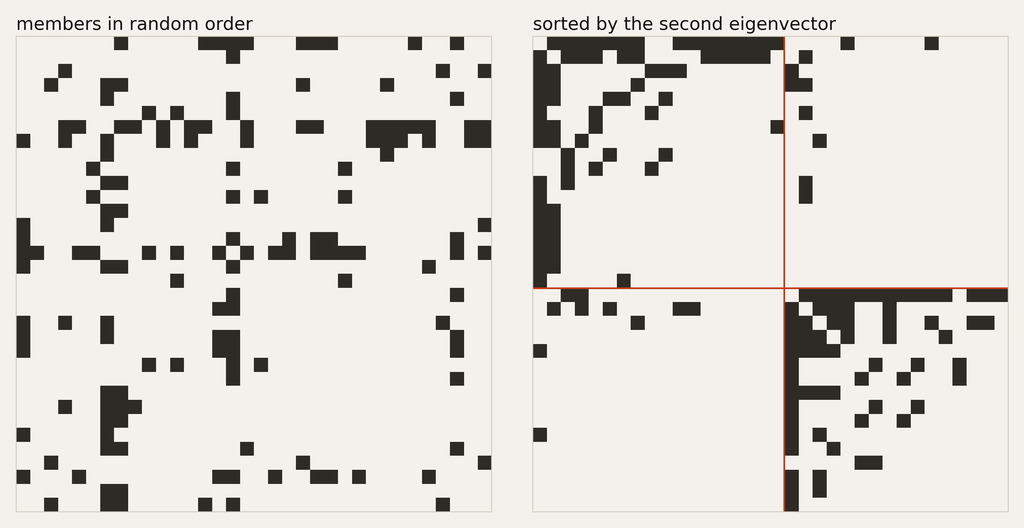

Left: the matrix with the members in random order. Noise.

Right: sorted by the sign of the Fiedler vector, the second eigenvector of L = D − A. Two blocks.

The cut puts 33 of the 34 members on the side they joined: the right panel of slide 32.

5 / can an algorithm find the groups?

MADS-DAV · 33

The algorithm, and the matrix that shows what it did. The Laplacian of a graph is the degree matrix minus the adjacency matrix, L = D − A. Its eigenvectors describe the graph's shape, and the second one, the Fiedler vector, gives every node a number such that nodes connected to each other get similar numbers. Splitting the nodes by the sign of that number cuts the graph in two with few edges between the halves. Nobody told it about the clubs. The left matrix is the club in a random order: no structure visible. The right one is the same matrix with the members sorted by the side of the Fiedler vector, and within a side by degree: two dark blocks on the diagonal, and few cells between them. That is what a group looks like in a matrix, and the drawing of the previous slide said the same: two clumps. And the cut agrees with history: 33 of 34 members land on the side they actually joined. This is the good case: eye, algorithm and an outcome measured separately all agree. Notebook 07.3, sections 7.3.2 and 7.3.3.

■ 5 — can an algorithm find the groups?

more than two groups

## Louvain maximises modularity

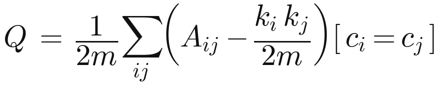

what Q counts

The edges inside your groups, minus the edges you would expect there if the same nodes, with the same degrees, were wired at random.

how to read it

Q = 0: no more inside than chance. The two clubs, as they actually split, score Q = 0.36.

what louvain does

An optimisation: a greedy search for the division with the highest Q. Each node in turn joins the neighbouring group that raises Q most; then every group becomes one node, and again.

Louvain returns groups for every network. Whether they are there is question six.

5 / can an algorithm find the groups?

MADS-DAV · 34

The Fiedler vector cuts in two. For more groups the standard tool is louvain, and it optimises a score you should be able to read: modularity, Q. For a given division into groups, Q takes the share of all edges that fall inside groups and subtracts the share you would expect inside those same groups if the edges were placed at random while every node kept its degree. So Q measures 'more inside than chance', and the degrees are the chance model; that detail matters in question six. The karate club divided into the two clubs it actually split into scores 0.36. Louvain searches for the division with the highest Q, and 'moving a node' means changing its label. It starts with every node in a group of its own. Then it visits the nodes one by one and puts each in the neighbouring group where Q rises most, or leaves it where it is; it repeats that until no single move raises Q. Then it treats every group as one node and does the same with the groups, merging them, until nothing raises Q any more. So yes, it is an optimisation of Q, but a greedy one: it finds a high Q, not guaranteed the highest, and with another random order of visiting it can end somewhere else. It decides the number of groups itself, through a resolution parameter you can turn. And it always returns a division, for every network you give it, including one with no groups at all.

■ 5 — can an algorithm find the groups?

louvain on the words of the chat